# Sparse Modeling Introduction and Practice

Modelscapes

2025-05-15

### Introduction to LASSO

LASSO, or the Least Absolute Shrinkage and Selection Operator model, is a sparse modeling method that was introduced by Tibshirani (1996) to address a core challenge in regression modeling: having a model that was both accurate and interpretable, especially when there are many covariates. In general, LASSO and other sparse methods are useful when you have many covariates, but only a few have a meaningful influence on the response variable. Sparse methods also excel in cases where there are a high number of covariates compared to the number of data points. Each sparse modeling method has its own way of selecting key covariates from the ‘white noise’ of multiple unimportant covariates.

It may be easiest to understand what LASSO does if you picture a linear model with many covariates ($X$s):
$$y = X_1
\beta_1 + X_2\beta_2 + X_3\beta_3... + X_{n}\beta_{n} + error$$
First, LASSO minimizes the Residual Sum of Squares [$\text{RSS} = \sum_{i=1}^n (y_i - \hat{y}_i)^2$] (which measures how well your model fits the data), *then adds a shrinkage penalty term* for the $\beta$s (betas): $\lambda \cdot \left| \sum \text{vector of $\beta$ coefficients} \right|$. This shrinkage penalty is the heart of the LASSO method: it reduces all $\beta$ coefficient estimates towards zero, and some are set to exactly zero; thus the covariates ($X$s) for the shrunken $\beta$s are also moved towards or set exactly to zero. In this shrinkage process, lambda ($\lambda$) is a tuning parameter that controls the amount of $\beta$ parameter shrinkage that occurs. In other words, the value of $\lambda$ determines how many $\beta$s will be set to 0: higher values of $\lambda$ result in more shrinkage and more $\beta$ coefficients being set exactly to zero, thus fewer $X$s selected as ‘important’ covariates (this IS NOT in a 1:1 relationship with the value of $\lambda$). Ideally, select a $\lambda$ that will minimize the shrinkage-penalty equation. The glmnet package has a function, ‘cv.glmnet()’ which we will use to find the best $\lambda$ value for our regularization and parameter selection.

**Data requirements:** For LASSO with glmnet, you need:  
X = a matrix of $X$ (covariate) values, where each column represents a particular covariate and each entry in the column is a data point for that covariate  
y = a vector of response values

**Limitations:** Why the glmnet package?: We are using the LASSO method embedded in the glmnet() package. This is one of the most popular and straightforward packages for running LASSO regression, however there are other options with slightly different implementations, notably the monomvn() package. In the next code chunk, you will load glmnet() along with the other packages used in this script. Once these packages are loaded, you can learn more about each one using the ‘help’ function: e.g., type and run help(glmnet) in your console, or search for glmnet in the ‘help’ tab in RStudio.

### Introduction to SuSiE

SuSiE, short for Sum of Single Effects, is a sparse method that arose from the field of genetics, as a tool for genetic fine mapping. Genetic fine mapping is a classic sparse problem- there are a huge number of candidate single nucleotide polymorphisms (SNPs) that could possibly affect some phenotype, and only a few of them are likely to truly have an effect. In addition, many of the SNPs are correlated with each other due to genetic linkage. SuSiE is built to both find the few truly explanatory variables out of many possible explanatory variables (variable selection), and pick out sets of correlated explanatory variables among which at least one has a strong effect (group selection).

The idea behind SuSiE is to make a Bayesian method similar to traditional forward step-wise selection, a method in which variables are added to a model one-by-one based on which improves the model performance the most (often determined by change in AIC). In fact, the authors named the algorithm used to fit SuSiE the iterative Bayesian step-wise selection (IBSS) algorithm in deference to this similarity. The main difference is that single effect regressions are fit using Bayesian methods, and at each step, there is quantified uncertainty in which variable to add to the model next, essentially resulting in model averaging at each step. In addition, the use of these distributions allows variable selections in previous steps to be evaluated again at each subsequent step.

Some advantages to SuSiE include its ease of use, its fast computational speed, its simple approximation algorithm compared to other exact Bayesian methods, and its ability to deal with correlated variables using group selection. Since SuSiE was created with genetics/genomics in mind, it can handle very large data sets. Some disadvantages are the possibility of the IBSS algorithm to have convergence issues with some data sets, and a lack of flexibility compared with some other Bayesian methods to deal with non-Gaussian data.

**Data requirements:** For SuSiE with susieR(), you need:  
X = a matrix of $X$ (covariate) values, where each column represents a particular covariate and each entry in the column is a data point for that covariate.  
y = a vector of response values

**Limitations:** In some cases, group selection can lead to poor estimates, due to splitting contributions among many correlated variables.

```r
# Load packages necessary for the following script.
library(tidyverse)
library(here)
library(susieR)
library(glmnet)
library(corrplot)
library(vioplot)
```

### Load Data

*This next part loads the dragon dataset.* In this exercise, we will walk through an example of comparing three methods, linear regression, LASSO, and SuSiE, as we try to figure out what controls dragon populations.

```r
# make analysis reproducible by setting a seed- any random number generation will be the same, with the same seed
set.seed(8712)

# load the data
data1=readRDS(here("data/dragon.data.RData")) #you can use this line instead if you clone the github repository and open it as a project
# otherwise just navigate to the downloaded data set in the popup window
# data1=readRDS(file.choose())

# data naming housekeeping
names(data1)[1]="X"
data1$X=as.matrix(data1$X)
```

### Understand the data

$$y = X_1 \beta_1 + X_2\beta_2 +
X_3\beta_3... + X_{74}\beta_{74} + error$$

Of these 74 covariates, only a few are actually important - the rest are ‘white noise’. This data structure is what makes a sparse method like LASSO or SuSiE a good choice for parameter selection: sparse methods excel at separating important parameters from the ‘white noise’.

### Visualize data

This data set consists of a response variable, the density of dragons, as well as 74 environmental and ecological covariates that might be important drivers of the dragon population density. We can visualize the range in population density by plotting a histogram of our response variable as well as looking at how it changes with a few of the environmental variables:

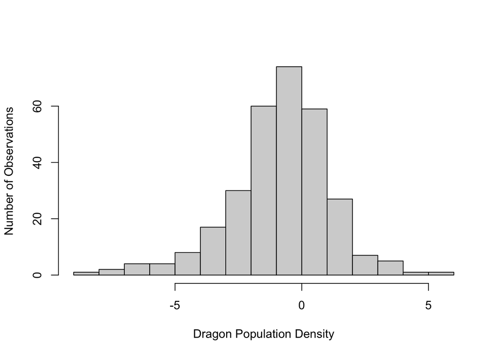

```r
# Make a histogram of the dragon population density, showing frequency for different ranges of population densities. Notice that population densities are shown as Z-scores, rather than true population densities. This means the original populations had their mean subtracted and were then divided by their standard deviation, in order to normalize them.
hist(data1$y, xlab = 'Dragon Population Density',
     ylab = 'Number of Observations', main = '')
```

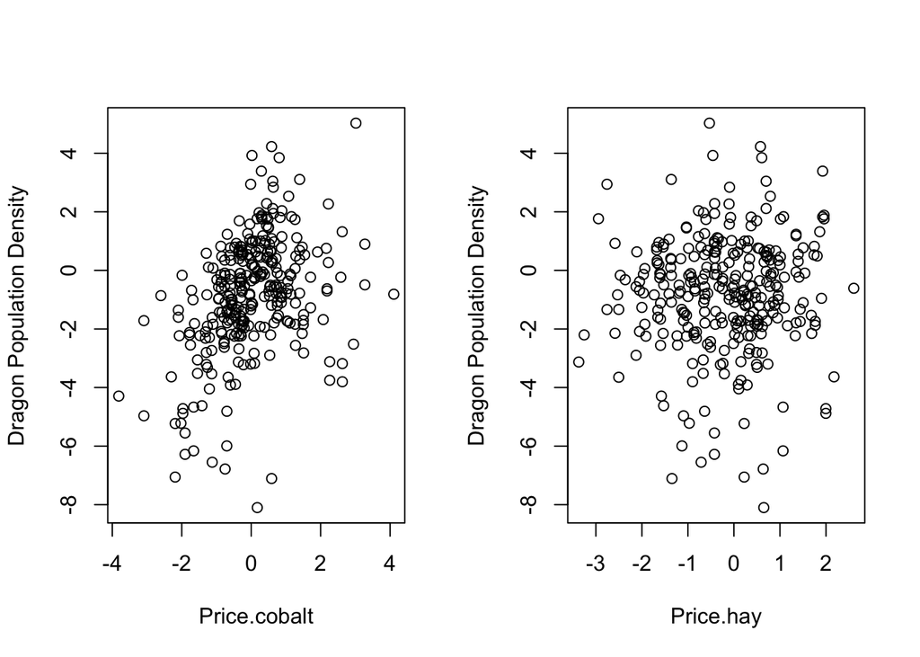

```r
# Make some exploratory plots showing the relationship between dragon frequency and the various explanatory variables- clearly density is not very correlated with the price of hay.
par(mfrow = c(1,2))
varnum1=1
plot(data1$X[,varnum1], data1$y,
     xlab = colnames(data1$X)[varnum1],
     ylab = 'Dragon Population Density')
varnum2=10
plot(data1$X[,varnum2], data1$y,
     xlab = colnames(data1$X)[varnum2],
     ylab = 'Dragon Population Density')
```

Only a few of the 74 covariates have meaningful effects. Because these are simulated data, we know which covariates are important before we start and can see this relationship for ourselves.

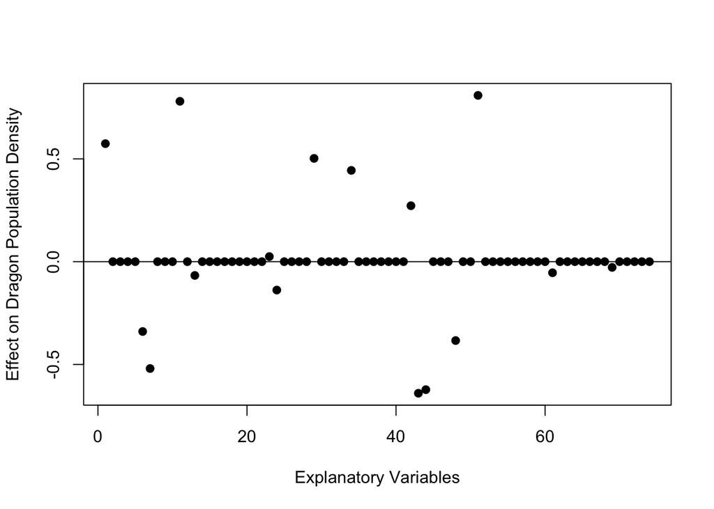

```r
# plot the known effect sizes of each explanatory variable on dragon population density
par(mfrow = c(1,1))
plot(data1$beta, pch = 19,
     xlab = 'Explanatory Variables',
     ylab = 'Effect on Dragon Population Density')
abline(h = 0)
```

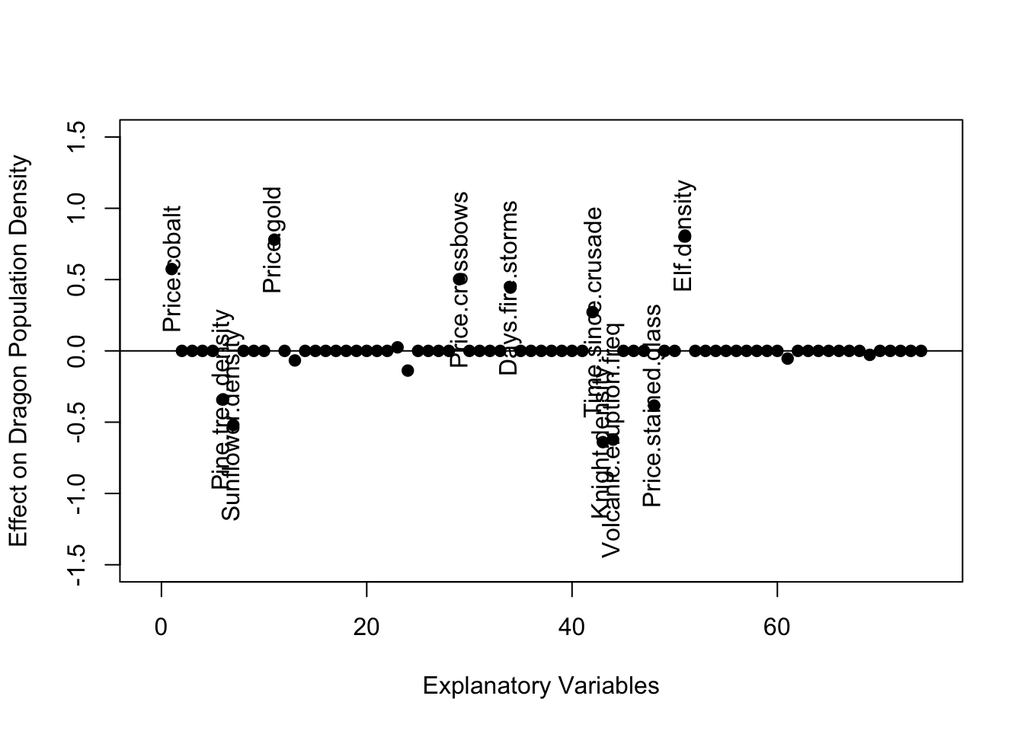

```r
plot(data1$beta, pch = 19,
     xlim=c(-1,75),
     ylim=c(-1.5,1.5),
     xlab = 'Explanatory Variables',
     ylab = 'Effect on Dragon Population Density')
abline(h = 0)

text(x=which(abs(data1$beta)>0.2),y=data1$beta[which(abs(data1$beta)>0.2)],colnames(data1$X)[which(abs(data1$beta)>0.2)],srt=90)
```

The challenge that we face is that many of these variables are correlated with each other, so it can be difficult to select the ones that are truly having strong effects from weaker but correlated covariates.

ACTIVITY 1: Consider which method(s) you expect to work best if highly correlated/uncorrelated variables have large effects? For strongly correlated variables, would LASSO or SuSiE be the best approach? Does it matter if the correlations occur among variables with large effects, between variables with large and small effects, or among variables with small effects?

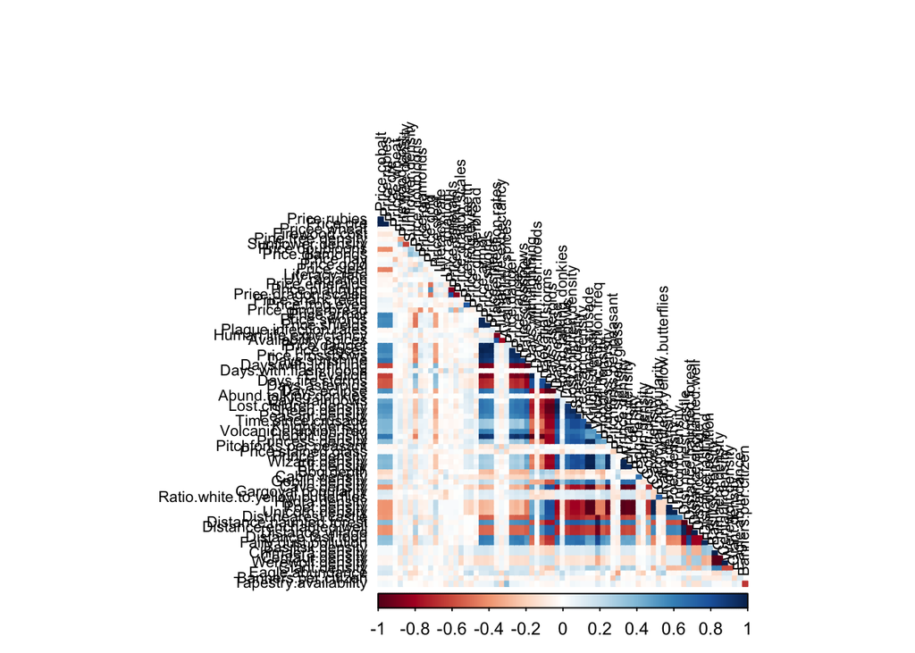

```r
# calculate correlation matrix showing correlation between each pair of explanatory variables
d <- cor(data1$X, use='complete.obs')

# visualize the correlation matrix:
# red is negative correlation, blue is positive correlation
# with paler colors being weaker correlations and darker colors being stronger correlations
# What does this plot tell you?
corrplot(d, type = "lower", order = 'original',tl.col = 'black',
         tl.srt = 90, tl.cex = 0.7, method = 'color', diag = FALSE)
```

### Linear Regression Model Fit

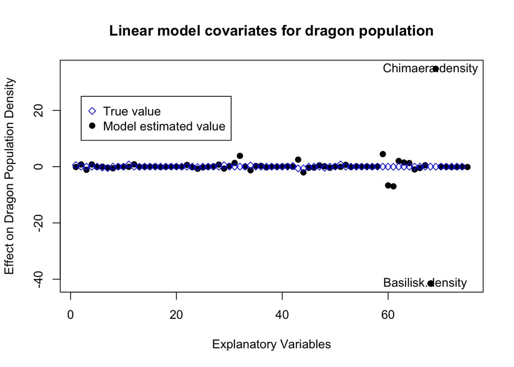

```r
# for comparison, try a simple linear regression model
l_mod <- lm(data1$y ~ data1$X)

# visualize the model estimates shown as black points
plot(l_mod$coefficients, pch = 19,
     xlab = 'Explanatory Variables',
     ylab = 'Effect on Dragon Population Density',
     main = "Linear model covariates for dragon population",
     ylim=c(min(-0.5,coef(l_mod)[-1],data1$beta), max(0.5,coef(l_mod)[-1],data1$beta)))
# compare to the real coefficients, shown as blue diamonds
points(data1$beta,pch=23,col="blue")
# the blue diamonds all appear really close to zero - but look at the y-axis values! The linear method vastly overestimates coefficients, dramatically increasing the scale (y axis limits) thus making the blue diamonds appear closer to zero than they actually are.
text(x=which(abs(l_mod$coefficients)>10)-1,y=l_mod$coefficients[which(abs(l_mod$coefficients)>10)],colnames(data1$X)[which(abs(l_mod$coefficients)>10)-1]) # minus 1 to exclude intercept
legend(2,25,legend=c("True value","Model estimated value"),col=c("blue","black"),pch=c(23,19))
```

```r
# examine the summary for more information about the linear model
summary(l_mod)
```

```
##
## Call:
## lm(formula = data1$y ~ data1$X)
##
## Residuals:
##      Min       1Q   Median       3Q      Max
## -2.70296 -0.48728 -0.04227  0.57053  2.12108
##
## Coefficients:
##                                            Estimate Std. Error t value Pr(>|t|)
## (Intercept)                               -0.131218   0.107490  -1.221   0.2235
## data1$XPrice.cobalt                        0.773916   0.785935   0.985   0.3258
## data1$XPrice.rubies                       -1.116951   0.908505  -1.229   0.2202
## data1$XPrice.ore                           0.792088   0.938752   0.844   0.3997
## data1$XPricee.wheat                       -0.084425   0.071599  -1.179   0.2396
## data1$XFirewood.cost                      -0.004771   0.073308  -0.065   0.9482
## data1$XPine.tree.density                  -0.341656   0.060265  -5.669 4.37e-08
## data1$XSunflower.density                  -0.572308   0.072241  -7.922 1.07e-13
## data1$XPrice.doubloons                    -0.021096   0.116997  -0.180   0.8571
## data1$XPrice.diamonds                     -0.042302   0.121218  -0.349   0.7274
## data1$XPrice.hay                          -0.061789   0.065794  -0.939   0.3487
## data1$XPrice.gold                          0.824028   0.059392  13.874  < 2e-16
## data1$XPrice.steel                        -0.015095   0.026314  -0.574   0.5668
## data1$XLiteracy.rate                      -0.014854   0.073047  -0.203   0.8390
## data1$XUV.radiation                       -0.026611   0.072058  -0.369   0.7123
## data1$XPrice.emeralds                      0.059915   0.104585   0.573   0.5673
## data1$XPrice.platinum                     -0.127373   0.192096  -0.663   0.5080
## data1$XPrice.dragon.scales                -0.052159   0.201348  -0.259   0.7958
## data1$XPrice.shark.teeth                   0.004610   0.021785   0.212   0.8326
## data1$XPrice.frog.eyes                     0.013556   0.031715   0.427   0.6695
## data1$XPrice.gingerbread                  -0.023003   0.046965  -0.490   0.6248
## data1$XPrice.armor                         0.619544   0.677712   0.914   0.3616
## data1$XPrice.swords                       -0.222793   0.452150  -0.493   0.6227
## data1$XPrice.shields                      -0.749076   2.061210  -0.363   0.7166
## data1$XPlague.infection.rates             -0.266383   0.184575  -1.443   0.1503
## data1$XHuman.life.expectancy              -0.069127   0.190540  -0.363   0.7171
## data1$XAvailability.spices                 0.073941   0.161651   0.457   0.6478
## data1$XPrice.dagger                        0.732390   0.913456   0.802   0.4235
## data1$XPrice.lances                       -0.684612   0.759748  -0.901   0.3685
## data1$XPrice.crossbows                     0.228243   0.514116   0.444   0.6575
```

[output cut: 112 more lines]

```
## data1$XFairy.dust.pollution
## data1$XBasilisk.density
## data1$XChimaera.density
## data1$XCentaur.density
## data1$XWerewolf.density
## data1$XGiant.density
## data1$XEagle.abundance
## data1$XBanners.per.citizen
## data1$XTapestry.availability
## ---
## Signif. codes:  0 '***' 0.001 '**' 0.01 '*' 0.05 '.' 0.1 ' ' 1
##
## Residual standard error: 1.036 on 225 degrees of freedom
## Multiple R-squared:  0.7974, Adjusted R-squared:  0.7307
## F-statistic: 11.96 on 74 and 225 DF,  p-value: < 2.2e-16
```

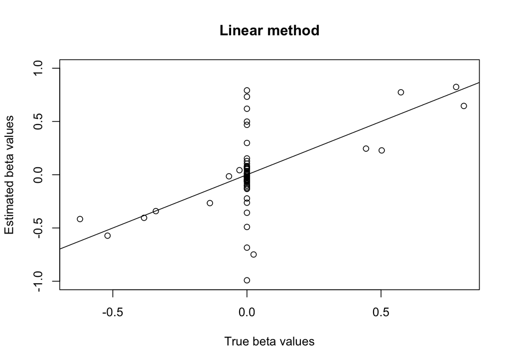

```r
# the adjusted r-squared value is *0.7307*, which indicates that model thinks it has described the majority of the variance.

# compare estimated coefficients to real values- if the model had perfect parameter recovery, the points would fall on the y=x line
plot(data1$beta,coef(l_mod)[-1],
     ylim=c(-1,1),
     xlab="True beta values",
     ylab="Estimated beta values",
     main="Linear method")
abline(a=0,b=1)
```

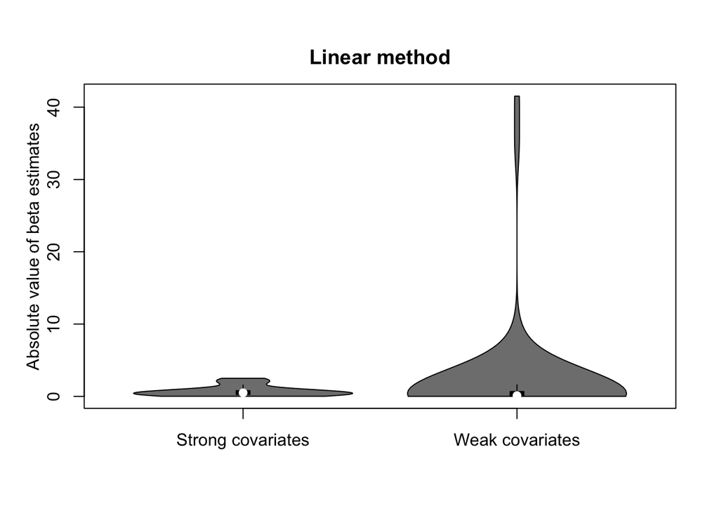

```r
# the vertical "line" of points means that the model is estimating high beta values even when the true values are zero

# Compare estimates for strong vs weak covariates in a boxplot
coefLinearNoIntercept=coef(l_mod)[-1]
strong=which(abs(data1$beta)>0)
vioplot(abs(coefLinearNoIntercept[strong]),abs(coefLinearNoIntercept[-strong]),ylab="",names=c("Strong covariates","Weak covariates"),main="Linear method")
mtext("Absolute value of beta estimates", side = 2, line = 2) # fixes the issue w. ylab and values overlapping
```

```r
# Unfortunately, some of the weak covariates have unrealistic estimates
```

### LASSO Model Fit

Fitting the data for a LASSO regularization is a straightforward process. There are two steps, each using a function from the ‘glmnet’ package, and with alpha ($\alpha$) set to 1 (in glmnet, $\alpha$=1 specifies LASSO regularization). First, use ‘cv.glmnet()’ to find the lambda_min, i.e. the $\lambda$ value that provides the lowest mean cross-validated error for your data. Once you have your lambda_min, call ‘glmnet()’, specifying that $\alpha$=1 and $\lambda$=lambda_min. In both functions, X is a table of covariates, with each column of X being one covariate, and y is a vector of y values.

ACTIVITY 2: What happens when you try different $\lambda$ values? Sure we show you how to choose $\lambda$ below, but as you work through the LASSO analysis, consider what would happen if you used different values of $\lambda$. How would increasing (or decreasing) $\lambda$ change the number of parameters selected, the estimates of those parameters, and the predictive ability of the model? Try to make a prediction before trying it, and then see if you were right, by trying a few different $\lambda$ values. What happens if the “best” $\lambda$ value is weird- really low or really high?

```r
# use k-fold cross-validation to find the best value for lambda
cv.model_lasso <- cv.glmnet(x=data1$X, y=data1$y, alpha=1)
best_lambda <- cv.model_lasso$lambda.min
best_lambda
```

```
## [1] 0.02119262
```

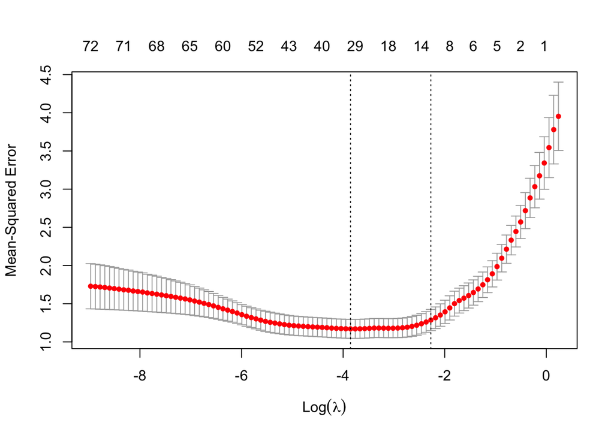

```r
# Lower values of lambda mean that beta values are less penalized. If lambda is zero, you are essentially back at the linear model

# Visualize the output lambdas. The best lambda value(s) that minimize the error are shown by the vertical dashed lines, which can be interpreted like confidence intervals. Note that the x-axis (lambda values) is in (natural) log space.
plot(cv.model_lasso)
```

```r
# use the selected best_lambda value to run the LASSO regression using glmnet()
model_lasso <- glmnet(x=data1$X, y=data1$y, alpha=1, lambda=best_lambda)  #match w dataset once finalized
```

```r
coef_lasso <- coef(model_lasso)[-1]
selected_covariates <- which(coef_lasso != 0)

# Notice that many of the 74 coefficient values do not appear: this is because LASSO shrank them to 0.
which(coef_lasso != 0)
```

```
##  [1]  1  4  6  7 10 11 12 15 16 17 20 24 27 29 32 34 37 44 46 47 48 50 53 54 56
## [26] 57 60 66 67 68 72 73 74
```

```r
# check the deviance explained by LASSO (interpret like r-squared value)
model_lasso$dev.ratio
```

```
## [1] 0.7628095
```

```r
# the model explained a good amount of deviance
```

### Model Results

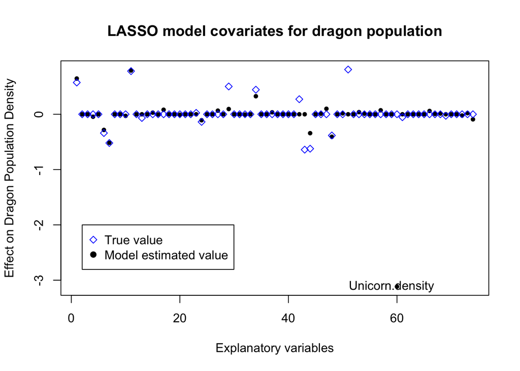

```r
# look at the estimates that LASSO has found for the beta values
plot(coef(model_lasso)[-1],
     pch = 20,
     main = 'LASSO model covariates for dragon population',
     ylab="Effect on Dragon Population Density",
     xlab="Explanatory variables",
     ylim=c(min(-0.5,coef(model_lasso)[-1],data1$beta),max(0.5,coef(model_lasso)[-1],data1$beta)))
# compare to the real coefficients, shown as blue diamonds
points(data1$beta,pch=23,col="blue")
text(x=which(abs(model_lasso$beta)>2)-1,y=model_lasso$beta[which(abs(model_lasso$beta)>2)],colnames(data1$X)[which(abs(model_lasso$beta)>2)])
legend(2,-2,legend=c("True value","Model estimated value"),col=c("blue","black"),pch=c(23,19))
```

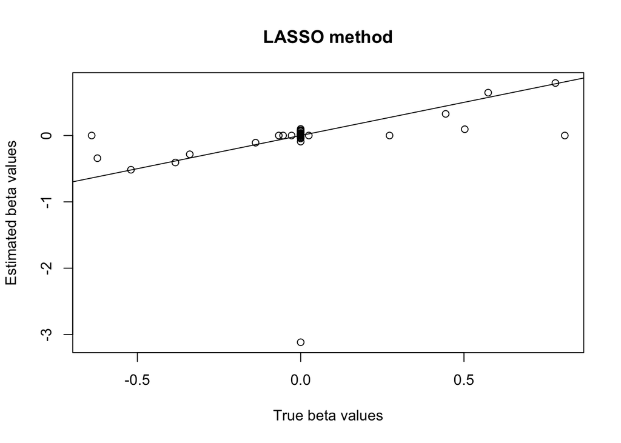

```r
# compare coefficients to real values- if the model had perfect parameter recovery, the points would fall on the y=x line
plot(data1$beta,coef(model_lasso)[-1],
     xlab="True beta values",
     ylab="Estimated beta values",
     main="LASSO method")
abline(a=0,b=1)
```

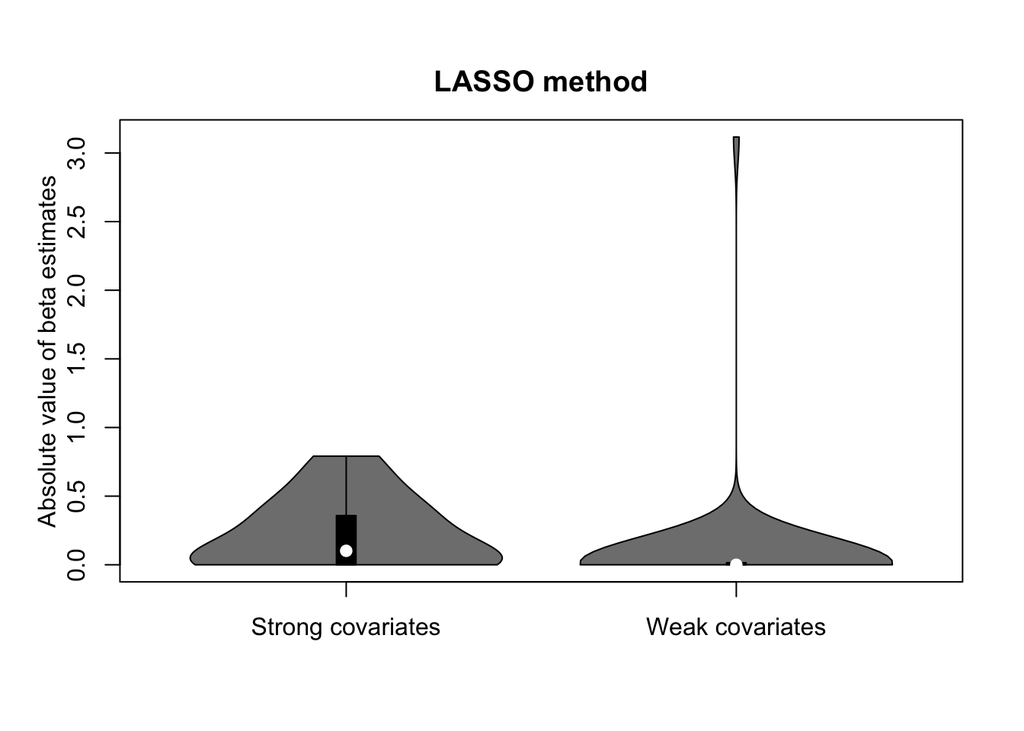

```r
# Compare estimates for strong vs weak covariates
coefLassoNoIntercept=coef(model_lasso)[-1]
strong=which(abs(data1$beta)>0)
vioplot(abs(coefLassoNoIntercept[strong]),abs(coefLassoNoIntercept[-strong]),ylab="",names=c("Strong covariates","Weak covariates"),main="LASSO method")
mtext("Absolute value of beta estimates", side = 2, line = 2) # fixes the issue w. ylab and values overlapping
```

```r
# Seems like LASSO is doing a mostly good job with the weak covariates, though one is abnormally high
```

### SuSiE model Fit

The actual fitting of the data is very simple, just call the SuSiE function. X is a table of covariate variables, with each column of X being a covariate, and y is a vector of y values. The parameter L is the maximum number of non-zero effects that you are allowing in your model- by default, L is set to either 10 or the number of variables in X, whichever is smaller. Of course, choosing your L value is a matter of judgement, but do note that L is the maximum number of non-zero effects, the number of covariate variables selected may be much smaller.

ACTIVITY 3: What happens when you try different L values? We chose L=10 for this analysis, but are you sure that is a good choice? How would increasing (or decreasing) L change the number of parameters selected, the estimates of those parameters, and the predictive ability of the model? Try to make a prediction before trying it, and then see if you were right, by trying a few different L values. SuSiE, unlike LASSO, doesn’t have a built in cross validation function for selecting an L value. How could you search systematically for the correct L value?

```r
# fit the model
model_susie <- susie(data1$X, data1$y, L = 10)
```

The main results from the summary function for SuSiE are a table of variables and a table of “credible sets”. Within the variable table, all selected non-zero effects are listed along with the variable’s inclusion probability and which credible set the variable belongs to. The credible sets summary includes a list of credible sets, and for each one a logged Bayes factor, an average $R^2$ value and a minimum $R^2$ value, as well as a list of which variables are in the credible set. When more than one variable is in a credible set, that means that the SuSiE suggests that these variables are correlated, and cannot determine which one should be included in the model.

The coefficient function tells us about what the coefficient estimates are for our SuSiE model. Since we are using simulated data, we can compare these to the real beta values.

```r
# examine the summary for the susie model
summary(model_susie)
```

```
##
## Variables in credible sets:
##
##  variable variable_prob cs
##         7    1.00000000  3
##        11    1.00000000  1
##         6    1.00000000  5
##        48    1.00000000  4
##        44    0.95253326  6
##         1    0.61477820  2
##         3    0.30328065  2
##        60    0.26185517  7
##        55    0.16837296  7
##        59    0.11051805  7
##        58    0.09199148  7
```

[output cut: 17 more lines]

```r
# you can see the credible sets- result of variable selection
```

```r
# examine the posterior inclusion probabilities calculated by susie
model_susie$pip
```

```
##                      Price.cobalt                      Price.rubies
##                      6.147782e-01                      8.194127e-02
##                         Price.ore                      Pricee.wheat
##                      3.032807e-01                      6.578182e-09
##                     Firewood.cost                 Pine.tree.density
##                      6.231909e-09                      1.000000e+00
##                 Sunflower.density                   Price.doubloons
##                      1.000000e+00                      8.766547e-09
##                    Price.diamonds                         Price.hay
##                      4.648895e-09                      5.116517e-09
##                        Price.gold                       Price.steel
##                      1.000000e+00                      8.871110e-09
##                     Literacy.rate                      UV.radiation
##                      4.497053e-09                      5.290302e-09
##                    Price.emeralds                    Price.platinum
##                      6.593453e-09                      8.296961e-09
##               Price.dragon.scales                 Price.shark.teeth
##                      9.804043e-09                      7.592674e-09
##                   Price.frog.eyes                 Price.gingerbread
##                      7.764276e-09                      4.840329e-09
##                       Price.armor                      Price.swords
##                      4.690410e-07                      4.390648e-07
##                     Price.shields            Plague.infection.rates
##                      2.190336e-07                      2.549218e-08
##             Human.life.expectancy               Availability.spices
##                      1.673557e-08                      1.018788e-08
##                      Price.dagger                      Price.lances
##                      1.553606e-07                      7.062736e-07
##                   Price.crossbows                     Days.sunshine
##                      1.189482e-07                      5.262292e-06
##               Days.with.lightning            Days.with.flash.floods
##                      5.810553e-06                      1.050581e-08
##                         Elevation                  Days.fire.storms
##                      2.238300e-06                      1.537882e-03
##                    Days.asteroids                      Days.eclipse
##                      7.291400e-04                      1.738750e-04
##             Abund.talking.donkies                     Days.rainbows
##                      1.026130e-08                      2.132559e-05
##             Lost.children.density                     Sheep.density
##                      5.538794e-05                      7.079255e-05
```

[output cut: 19 more lines]

```
##                      1.105181e-01                      2.618552e-01
##               Dist.nearest.castle           Distance.haunted.forest
##                      1.880444e-02                      1.297189e-02
##           Distance.enchanted.well                  Distance.village
##                      5.834730e-03                      7.227462e-03
##                Distance.fast.food              Fairy.dust.pollution
##                      7.649783e-05                      7.887042e-06
##                  Basilisk.density                  Chimaera.density
##                      1.801608e-08                      1.803762e-08
##                   Centaur.density                  Werewolf.density
##                      1.347774e-08                      1.467268e-08
##                     Giant.density                   Eagle.abundance
##                      1.989961e-08                      5.456698e-09
##               Banners.per.citizen             Tapestry.availability
##                      8.086086e-09                      2.545986e-08
```

```r
# calculate the susie model r-squared values
rsquared=cor(predict(model_susie,data1$X),data1$y)^2
rsquared
```

```
## [1] 0.7303086
```

```r
# r squared value is decently high
```

### SuSiE Model Results

SuSiE has its own plotting method, which shows the posterior inclusion probability of each variable in X. It’s also useful to look at a plot of the coefficients themselves.

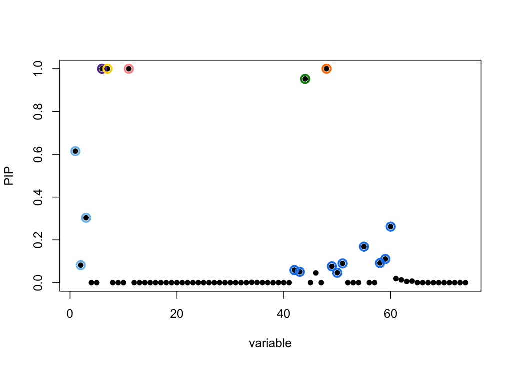

```r
susie_plot(model_susie, y="PIP")
```

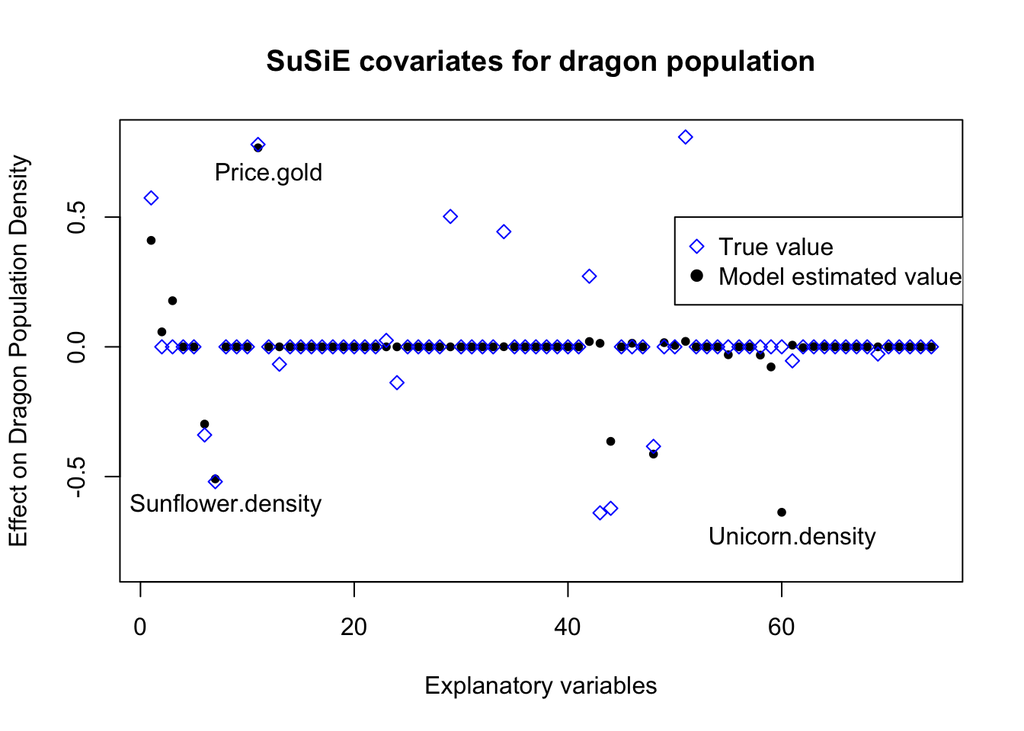

```r
# the color coding in this first plot shows the credible sets

# remove the first item, as it is the intercept
# plot the estimates from SuSiE as black points
plot(coef(model_susie)[-1],
     pch = 20,
     main="SuSiE covariates for dragon population",
     ylab="Effect on Dragon Population Density",
     xlab="Explanatory variables",
     ylim=c(min(-0.5,coef(model_susie)[-1],data1$beta)-0.2,max(0.5,coef(model_susie)[-1],data1$beta)))
# compare to the real coefficients, shown as blue diamonds
points(data1$beta,pch=23,col="blue")
text(x=which(abs(coef(model_susie))>0.5),y=coef(model_susie)[which(abs(coef(model_susie))>0.5)]-0.1,colnames(data1$X)[which(abs(coef(model_susie))>0.5)-1])
legend(50,0.5,legend=c("True value","Model estimated value"),col=c("blue","black"),pch=c(23,19))
```

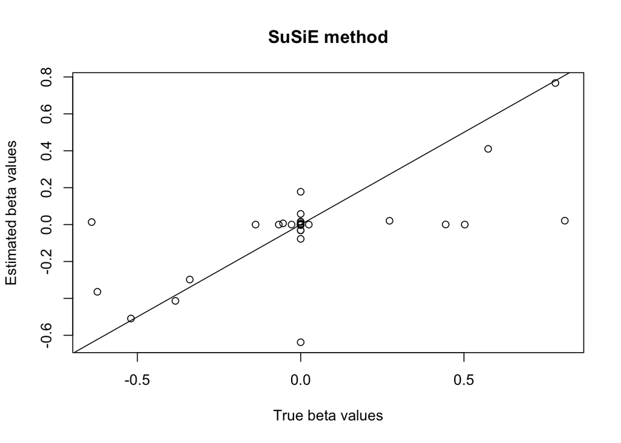

```r
# compare coefficients to real values- if the model had perfect parameter recovery, the points would fall on the y=x line
plot(data1$beta,coef(model_susie)[-1],
     xlab="True beta values",
     ylab="Estimated beta values",
     main="SuSiE method")
abline(a=0,b=1)
```

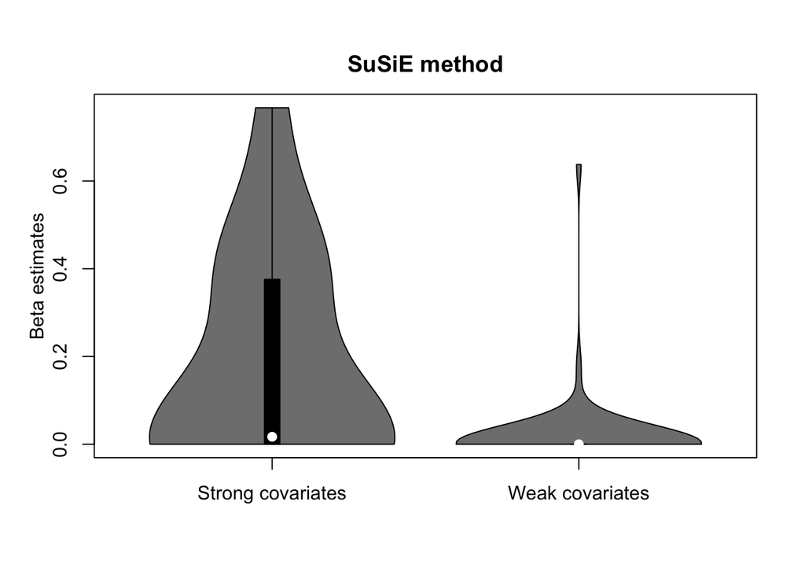

```r
# Compare estimates for strong vs weak covariates
coefSusieNoIntercept=coef(model_susie)[-1]
strong=which(abs(data1$beta)>0)
vioplot(abs(coefSusieNoIntercept[strong]),abs(coefSusieNoIntercept[-strong]),ylab="",names=c("Strong covariates","Weak covariates"),main="SuSiE method")
mtext("Beta estimates", side = 2, line = 2) # fixes the issue w. ylab and values overlapping
```

### Compare models in their predictive ability

```r
# split into training and testing- randomly choose 1/4 data to hold out as testing data
# randomize rows (observations)
dataSize=length(data1$y)
randomizer=sample(1:dataSize,size=dataSize,replace=F)

# select 3/4 of data to be included in training data
trainX=data1$X[randomizer[1:round(.75*dataSize)],]
trainY=data1$y[randomizer[1:round(.75*dataSize)]]

# remaining 1/4 of data to be included in testing data
testX=data1$X[-randomizer[1:round(.75*dataSize)],]
testY=data1$y[-randomizer[1:round(.75*dataSize)]]

# make the linear model using the training data
pred_model_lin=lm(trainY~.,data=data.frame(trainX))

# test the linear model using the testing data
pred_test_lin=predict(pred_model_lin, newx=testX)
rmse_test_lin=sqrt(mean((pred_test_lin-testY)^2))

# make the LASSO using the training data
pred_model_lasso=glmnet(x=trainX, y=trainY, alpha=1, lambda=best_lambda)

# test the LASSO model using the testing data
pred_test_lasso=predict(pred_model_lasso, newx=testX)
rmse_test_lasso=sqrt(mean((pred_test_lasso-testY)^2))

# make the SuSiE using the training data
pred_model_susie=susie(trainX, trainY, L=10)

# test the SuSiE model using the testing data
pred_test_susie=predict(pred_model_susie, newx=testX)
rmse_test_susie=sqrt(mean((pred_test_susie-testY)^2))



# raw RMSE values don't tell us a ton unless they are compared between methods
# remember higher values mean a worse performance. Which method performs the best?
rmse_test_lin
```

```
## [1] 2.853748
```

```r
rmse_test_lasso
```

```
## [1] 1.154294
```

```r
rmse_test_susie
```

```
## [1] 1.227097
```

### Compare models in their predictive ability and coefficient recovery

Cross validation is a tool that allows us to see how well a model is doing by splitting a data set into “training” and “testing” data sets. The training data set is used to fit the model, and then the testing data set is used to evaluate the performance of the model. We then switch it around so that different data are in the testing data set, so we are testing our model several times, and then we can see how our model is performing! Using k-folds cross validation, we split the data into k subsets, and then we use 1/k of the data for testing, and (k-1)/k for training, resulting in k tests of our data. While this technique is useful for sparse modeling approaches, it is also useful for any model fitting approach. In our k-folds cross validation, we evaluate our model using both prediction RMSE and by comparing the model’s fitted effect sizes with the true effect sizes.

ACTIVITY 4: What happens if you change the number of subsets, k, that you use for cross validation? Does randomness seem to affect the results more, or less, when you increase (or decrease) k? Can k be too high? Are there other ways to do cross validation that you think could work better?

BONUS DISCUSSION QUESTION: Why are some beta values poorly recovered across all the methods, while some are more easily recovered? Is there anything we can do about this?

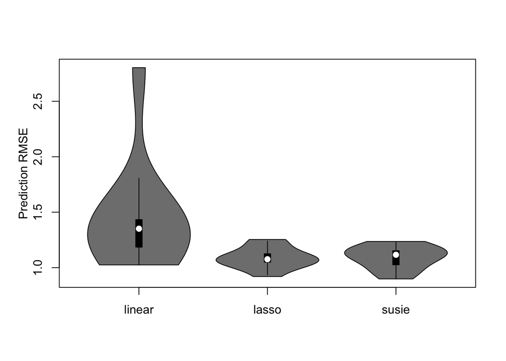

```r
set.seed(901284)

dataSize=length(data1$y)
k=10

# randomize data before subsetting
randomizer=sample(1:dataSize,size=dataSize,replace=F)

# place to save RMSE and parameter estimates across runs
rmse_vector_linear=numeric(k)
rmse_vector_lasso=numeric(k)
rmse_vector_susie=numeric(k)
rsquared_vector_linear=numeric(k)
rsquared_vector_lasso=numeric(k)
rsquared_vector_susie=numeric(k)
rsquared_vector_linear2=numeric(k)
rsquared_vector_lasso2=numeric(k)
rsquared_vector_susie2=numeric(k)
coef_table_linear=numeric(ncol(data1$X)+1)
coef_table_lasso=numeric(ncol(data1$X)+1)
coef_table_susie=numeric(ncol(data1$X)+1)
real_table=data1$beta

# define the subsets
for(i in 1:k){
  # get i'th subset and make it the testing data
  testy=data1$y[randomizer[round(1+(dataSize/k*(i-1))):round(dataSize/k*(i))]]
  testX=data1$X[randomizer[round(1+(dataSize/k*(i-1))):round(dataSize/k*(i))],]
  # set other subsets (rest of the data) to training data
  trainy=data1$y[-randomizer[round(1+(dataSize/k*(i-1))):round(dataSize/k*(i))]]
  trainX=data1$X[-randomizer[round(1+(dataSize/k*(i-1))):round(dataSize/k*(i))],]
  # run the model fits with the training data
  model_train_linear <- lm(trainy~.,data=data.frame(trainX))
  model_train_lasso <- glmnet(x=trainX, y=trainy, alpha=1, lambda=best_lambda)
  model_train_susie <- susie(trainX, trainy, L = 10)
  # test using the testing data- use the model to predict, then calculate RMSE, and pull the parameter estimates
  # save result and proceed
  pred_test_linear=predict.lm(model_train_linear, newdata=data.frame(testX))
  pred_test_lasso=predict(model_train_lasso, newx=testX)
  pred_test_susie=predict(model_train_susie, newx=testX)

  rmse_vector_linear[i]=sqrt(mean((pred_test_linear-testy)^2))
  rmse_vector_lasso[i]=sqrt(mean((pred_test_lasso-testy)^2))
  rmse_vector_susie[i]=sqrt(mean((pred_test_susie-testy)^2))

  rsquared_vector_linear[i]=cor(predict(model_train_linear,as.data.frame(trainX)),trainy)^2
  rsquared_vector_lasso[i]=cor(predict(model_train_lasso,trainX),trainy)^2
  rsquared_vector_susie[i]=cor(predict(model_train_susie,trainX),trainy)^2

  rsquared_vector_linear2[i]=cor(predict(model_train_linear,data.frame(testX)),testy)^2
  rsquared_vector_lasso2[i]=cor(predict(model_train_lasso,testX),testy)^2
  rsquared_vector_susie2[i]=cor(predict(model_train_susie,testX),testy)^2

  coef_table_linear=rbind(coef_table_linear,coef(model_train_linear))
  coef_table_lasso=rbind(coef_table_lasso,coef(model_train_lasso)[,1])
  coef_table_susie=rbind(coef_table_susie,coef(model_train_susie))
  # update table of real coefficients in the same format as the table of estimated coefficients
  real_table=rbind(real_table,data1$beta)
}

# remove row of zeros
coef_table_linear=coef_table_linear[-1,]
coef_table_lasso=coef_table_lasso[-1,]
coef_table_susie=coef_table_susie[-1,]

# visualize results of cross-validation- Evaluate predictive ability

vioplot(rmse_vector_linear,rmse_vector_lasso,rmse_vector_susie,names = c("linear","lasso","susie"),ylab="")
mtext("Prediction RMSE", side = 2, line = 2) # fixes the issue w. ylab and values overlapping
```

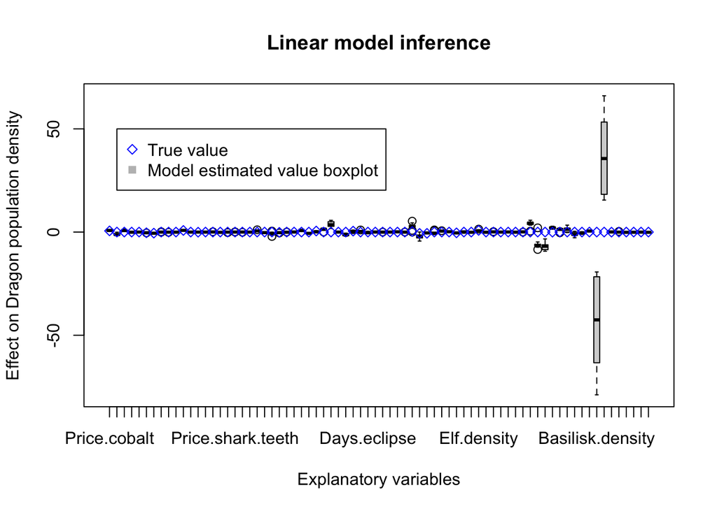

```r
# visualize results of cross-validation- Evaluate variable selection ability (inference)
# The gray boxplots show the distribution of estimates, while the blue diamonds show the true values
# If the boxplots are both small in range (precise) and on top of the blue diamonds (accurate), then the model is doing a great job
# Why do you think certain betas are difficult to recover across methods?

boxplot(coef_table_linear[,-1],main="Linear model inference",xlab="Explanatory variables",ylab="Effect on Dragon population density") # omit the 1st column (intercept estimate)
points(data1$beta,pch=23,col="blue")
legend(2,50,legend=c("True value","Model estimated value boxplot"),col=c("blue","grey"),pch=c(23,15))
```

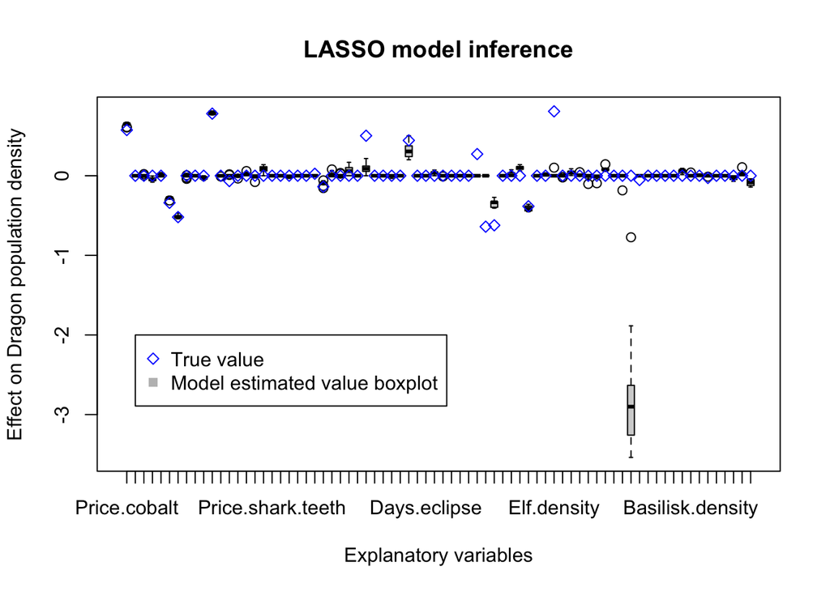

```r
boxplot(coef_table_lasso[,-1],main="LASSO model inference",xlab="Explanatory variables",ylab="Effect on Dragon population density") # omit the 1st column (intercept estimate)
points(data1$beta,pch=23,col="blue")
legend(2,-2,legend=c("True value","Model estimated value boxplot"),col=c("blue","grey"),pch=c(23,15))
```

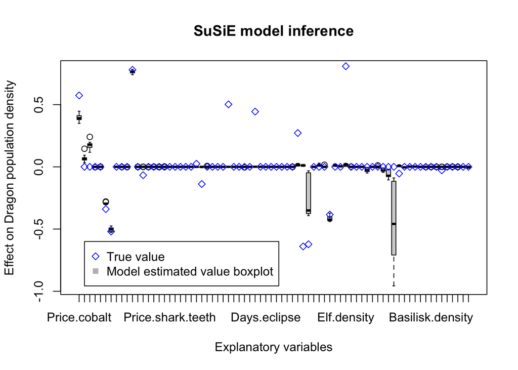

```r
boxplot(coef_table_susie[,-1],main="SuSiE model inference",xlab="Explanatory variables",ylab="Effect on Dragon population density") # omit the 1st column (intercept estimate)
points(data1$beta,pch=23,col="blue")
legend(2,-0.6,legend=c("True value","Model estimated value boxplot"),col=c("blue","grey"),pch=c(23,15))
```

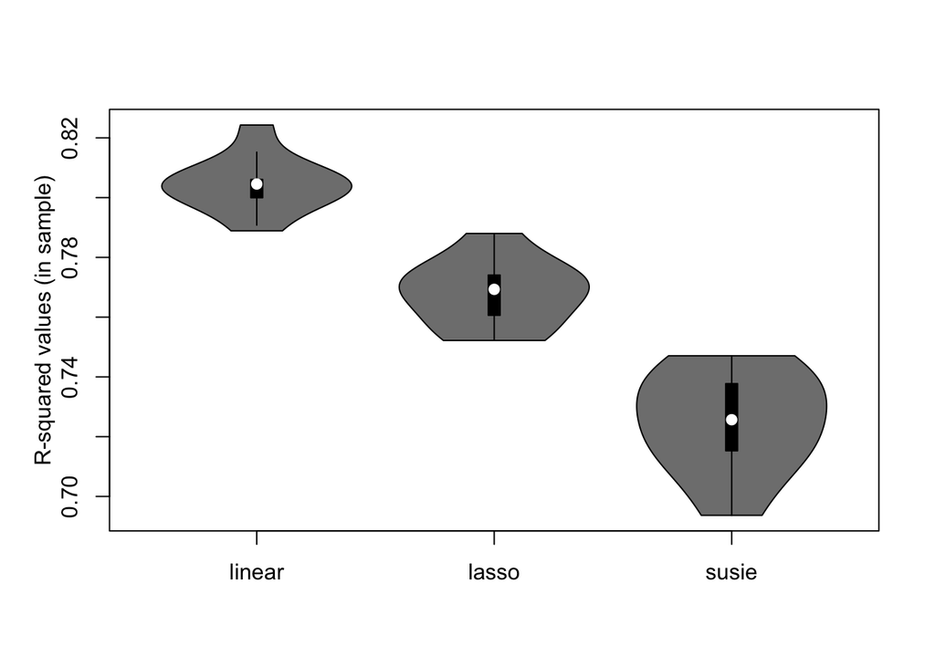

```r
# Though the sparse methods perform inference better than the linear model, the sparse methods are not perfect

# Visualize r-squared metrics
# in sample
vioplot(rsquared_vector_linear,rsquared_vector_lasso,rsquared_vector_susie,names = c("linear","lasso","susie"),ylab="")
mtext("R-squared values (in sample)", side = 2, line = 2) # fixes the issue w. ylab and values overlapping
```

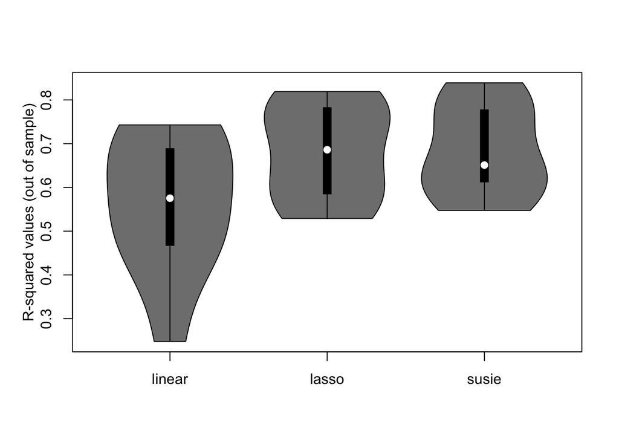

```r
# out of sample
vioplot(rsquared_vector_linear2,rsquared_vector_lasso2,rsquared_vector_susie2,names = c("linear","lasso","susie"),ylab="")
mtext("R-squared values (out of sample)", side = 2, line = 2) # fixes the issue w. ylab and values overlapping
```

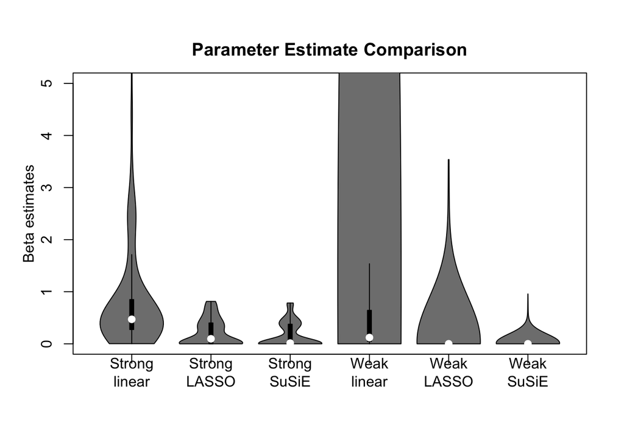

```r
# Visualize estimates
# remove intercept estimates
coef_table_linear1=coef_table_linear[,-1]
coef_table_lasso1=coef_table_lasso[,-1]
coef_table_susie1=coef_table_susie[,-1]

strong=which(abs(data1$beta)>0)
vioplot(abs(as.vector(coef_table_linear1[,strong])),abs(as.vector(coef_table_lasso1[,strong])),abs(as.vector(coef_table_susie1[,strong])),abs(as.vector(coef_table_linear1[,-strong])),abs(as.vector(coef_table_lasso1[,-strong])),abs(as.vector(coef_table_susie1[,-strong])),ylab="",names=c("Strong\nlinear","Strong\nLASSO","Strong\nSuSiE","Weak\nlinear","Weak\nLASSO","Weak\nSuSiE"),main="Parameter Estimate Comparison",ylim=c(0,5))
mtext("Beta estimates", side = 2, line = 2) # fixes the issue w. ylab and values overlapping
```

For additional information about the `glmnet` package and further example vignettes, please visit https://glmnet.stanford.edu/index.html.

For additional information about the `susieR` package and further example vignettes, please visit https://stephenslab.github.io/susieR/.